# TCGA Plot Caller Comparisons

C. Savonen for ALSF CCDL

2020

Purpose: After creating a TCGA consensus file with `02-merge_callers.R`, this notebook plots these data in a series of plots to compare the consensus calls to the individual callers.

### Summary of Findings:

Lancet does not appear to be doing well with the WXS data. See the further analyses on this in the `lancet-wxs-tests` folder in this analysis folder.

**Table of Contents** *generated with [DocToc](https://github.com/thlorenz/doctoc)*

- Setup
- Connect to database
- Get consensus numbers
- Upset graphs
- VAF distribution for each caller
- VAF correlations
- Base changes
- Mutation region barplot
- Session Info

### Usage

To run this from the command line, use:

```
Rscript -e "rmarkdown::render('analyses/snv-callers/compare_snv_callers_plots-tcga.Rmd',
                              clean = TRUE)"
```

*This assumes you are in the top directory of the repository.*

## Setup

Read in set up script.

```r
# Magrittr pipe
`%>%` <- dplyr::`%>%`
```

Set up directories.

```r
scratch_dir <- file.path("..", "..", "scratch")
plots_dir <- file.path("plots", "tcga-caller-comparison")

if (!dir.exists(plots_dir)) {
  dir.create(plots_dir)
}
```

Import custom function for upset plot.

```r
source(file.path("util", "upset_plot.R"))
```

## Connect to TCGA database

Connect to SQLite database.

```r
# Start up connection
con <- DBI::dbConnect(RSQLite::SQLite(),
                      file.path(scratch_dir, "tcga_snv_db.sqlite"))
```

Note what columns we will join by.

```r
join_cols = c("Chromosome",
              "Start_Position",
              "Reference_Allele",
              "Allele",
              "Tumor_Sample_Barcode",
              "Variant_Classification")
```

Set up tables from the database but only call the columns we need.

```r
strelka <- dplyr::tbl(con, "strelka") %>%
  dplyr::select(join_cols, "VAF") %>%
  as.data.frame()

lancet <- dplyr::tbl(con, "lancet") %>%
  dplyr::select(join_cols, "VAF") %>%
  as.data.frame()

mutect <- dplyr::tbl(con, "mutect") %>%
  dplyr::select(join_cols, "VAF") %>%
  as.data.frame()
```

Full join to get the summary of mutations called by each caller.

```r
# Bring out the data.frame
all_caller_df <- strelka %>%
  dplyr::full_join(mutect, by = join_cols,
                   suffix = c("_strelka", "_mutect")) %>%
  dplyr::full_join(lancet,
                   by = join_cols) %>%
  dplyr::rename(VAF_lancet = VAF) %>%
  # We'll use this to keep track of the original rows/mutations
  tibble::rowid_to_column("index")

# Take a peek at what this looks like
head(all_caller_df)
```

|  | index | Chromosome | Start_Position | Reference_Allele | Allele | Tumor_Sample_Barcode | Variant_Classification | VAF_strelka | VAF_mutect | VAF_lancet |
| --- | --- | --- | --- | --- | --- | --- | --- | --- | --- | --- |
| 1 | 1 | chr17 | 41622908 | G | A | TCGA-CS-6668-01A-11D-1893-08 | Intron | 0.45714286 | 0.4578313 | NA |
| 2 | 2 | chr19 | 48499825 | C | A | TCGA-CS-6668-01A-11D-1893-08 | Missense_Mutation | 0.20000000 | NA | NA |
| 3 | 3 | chr17 | 3679667 | C | A | TCGA-CS-6668-01A-11D-1893-08 | Missense_Mutation | 0.09615385 | NA | NA |
| 4 | 4 | chr17 | 27631255 | G | A | TCGA-CS-6668-01A-11D-1893-08 | 5'UTR | 0.04964539 | NA | 0.04310345 |
| 5 | 5 | chr2 | 135846442 | C | T | TCGA-CS-6668-01A-11D-1893-08 | Intron | 0.56521739 | 0.5714286 | NA |
| 6 | 6 | chr17 | 3215782 | C | T | TCGA-CS-6668-01A-11D-1893-08 | Silent | 0.02270148 | NA | NA |

## Get consensus numbers

Make a data.frame with only the VAFs and turn into detected or not.

```r
detect_mat <- all_caller_df %>%
 # Bring over VAF columns and the index
 dplyr::select(dplyr::starts_with("VAF_")) %>%
 as.matrix()

# Store the indices as dimnames
dimnames(detect_mat)[[1]] <- all_caller_df$index

# Turn into detected or not
detect_mat <- !is.na(detect_mat)
```

Count up how many callers call each mutation.

```r
# Add up how many callers identify each mutation
consensus_count <- rowSums(detect_mat)

# Remove the 0's
consensus_count <- consensus_count[which(consensus_count != 0)]
```

Print out the numbers for the three callers’ consensus.

```r
cat(" At least 1 out of 3:", length(consensus_count), "\n",
    "At least 2 out of 3:", sum(consensus_count >= 2), "\n",
    "3 out of 3:", sum(consensus_count == 3))
```

```
 At least 1 out of 3: 138482
 At least 2 out of 3: 47987
 3 out of 3: 27841
```

## Upset graphs

Make the upset plot.

```r
upset_png(detect_mat,
          plot_file_path = file.path(plots_dir, "tcga-upset-plot.png"),
          has_vardict = FALSE)
```

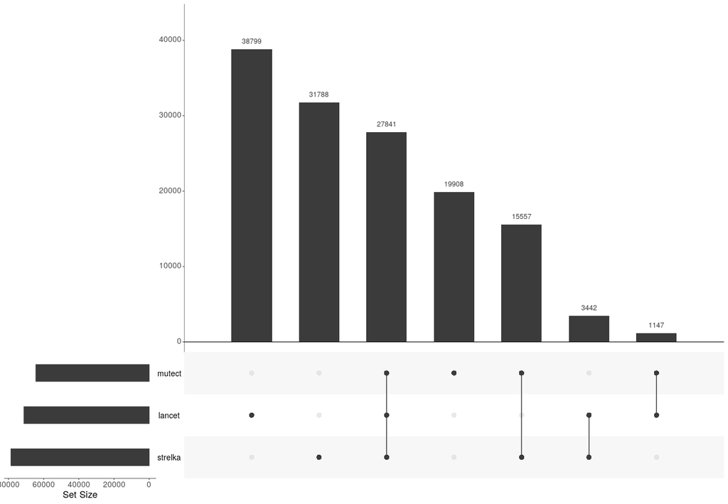

Upset plot - all data

Transcripts only upset plot.

```r
transcripts <- !(all_caller_df$Variant_Classification %in% c("5'Flank", "3'Flank", "IGR", "Intron"))

upset_png(detect_mat,
          plot_file_path = file.path(plots_dir, "tcga-upset-plot-transcipts-only.png"),
          subset_vector = transcripts,
          has_vardict = FALSE)
```

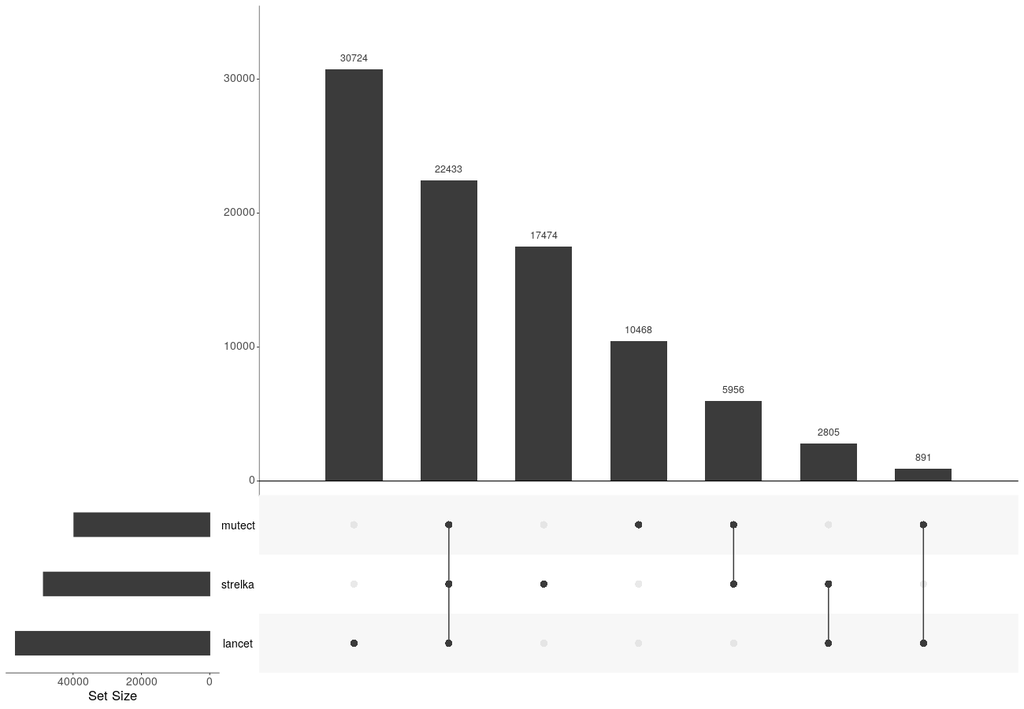

Upset plot - transcripts only

Non transcript upset plot.

```r
not_transcripts <- all_caller_df$Variant_Classification %in% c("5'Flank", "3'Flank", "IGR", "Intron")

upset_png(detect_mat,
          plot_file_path = file.path(plots_dir, "tcga-upset-plot-not-transcipts-only.png"),
          subset_vector = not_transcripts,
          has_vardict = FALSE)
```

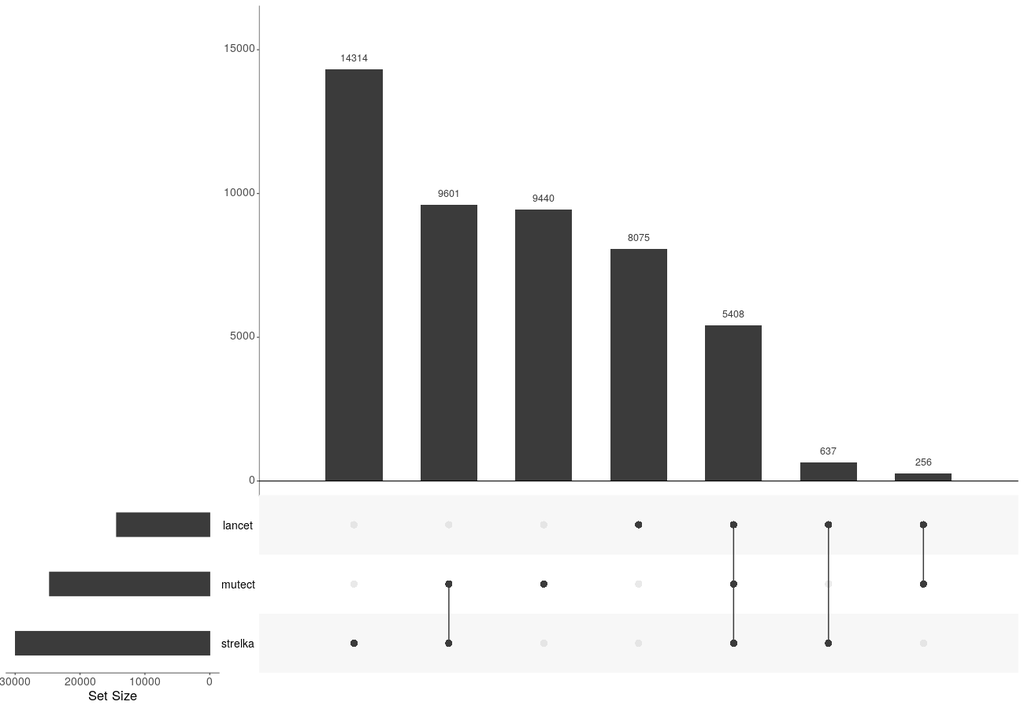

Upset plot - non-transcripts only

## VAF distribution for each caller

Create consensus VAF based on strelka’s VAFs and which mutations would be included.

```r
# Make new VAF column based on strelka's VAFs
all_caller_df$VAF_consensus <- all_caller_df$VAF_strelka

# Figure out which mutations are not in the consensus
not_consensus <- dimnames(consensus_count)[[1]][which(consensus_count < 3)]

# Make non consensus mutations in consensus)VAF an NA
all_caller_df$VAF_consensus[not_consensus] <- NA
```

Make a long form VAF data.frame for exploring mutations VAFs from each caller.

```r
vaf_df <- all_caller_df %>%
  dplyr::select(index, dplyr::starts_with("VAF_"), Variant_Classification) %>%
  # Make long format
  tidyr::gather(key = "caller", value = "vaf", -index, -Variant_Classification) %>%
  # Drop the `VAF_`
  dplyr::mutate(caller = gsub("VAF_", "", caller)) %>%
  dplyr::filter(!is.na(vaf))
```

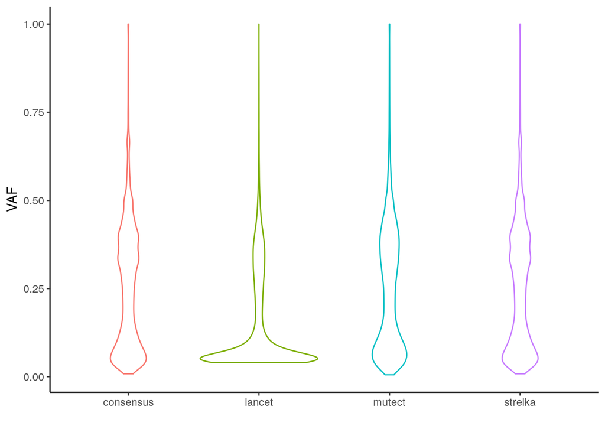

```r
# Make this plot
vaf_plot <- vaf_df %>%
  ggplot2::ggplot(ggplot2::aes(x = caller, y = vaf, color = caller)) +
  ggplot2::geom_violin() +
  ggplot2::theme_classic() +
  ggplot2::xlab("") +
  ggplot2::ylab("VAF") +
  ggplot2::theme(legend.position = "none")

# Print out
vaf_plot
```

Lancet appears to be calling quite a few low VAF mutations.

```r
# Save this plot
ggplot2::ggsave(plot = vaf_plot,
                file.path(plots_dir, "tcga-vaf-distribution-plot.png"))
```

## VAF correlations

Correlate VAF’s across callers.

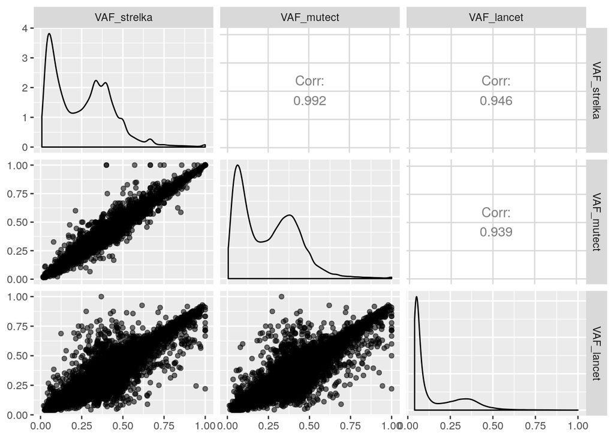

```r
cor_vaf <- all_caller_df %>%
  dplyr::select(dplyr::starts_with("VAF_"), -VAF_consensus) %>%
  GGally::ggpairs(mapping = ggplot2::aes(alpha = 0.05))
# Print out without progress bar
cor_vaf %>%
  print(progress = FALSE)
```

VAF’s are pretty related across callers.

```r
ggplot2::ggsave(filename = file.path(plots_dir, "tcga-vaf-cor-matrix.png"),
                plot = cor_vaf)
```

## Base changes

Summarize base change information per caller.

```r
# Summarize by the number of times each base change shows up in each category.
frac_change_df <- all_caller_df %>%
  # Select only the columns we need
  dplyr::select(index, Allele, Reference_Allele) %>%
  # Make change variable
  dplyr::mutate(base_change = paste0(Allele, ">", Reference_Allele)) %>%
  dplyr::mutate(
    # From the base_change variable, summarize insertions, deletions, and
    # changes that are more than one base into their own groups.
    change = dplyr::case_when(
      grepl("^-", base_change) ~ "ins",
      grepl("-$", base_change) ~ "del",
      nchar(base_change) > 3 ~ "long_change",
      TRUE ~ base_change
    )
  ) %>%
  # Join vaf_data
  dplyr::inner_join(vaf_df, by = "index") %>%
  # Summarize the number of mutations per caller
  dplyr::count(caller, change, name = "count") %>%
  dplyr::add_count(caller, wt = count) %>%
  # Calculate the percent of each
  dplyr::mutate(percent = count / n) %>%
  # Drop nonsensical changes
  dplyr::filter(!grepl("N>*|*>N|C>C|T>T|A>A|G>G", change),
                !is.na(change)) %>%
  dplyr::mutate(
    change = as.factor(change),
    # Change factor level order so ins and del are at the end
    change = forcats::fct_relevel(change, "ins", "del", "long_change", after = Inf)
  )
```

Make a barplot illustrating the percent of the mutations for each caller that that are each type of change.

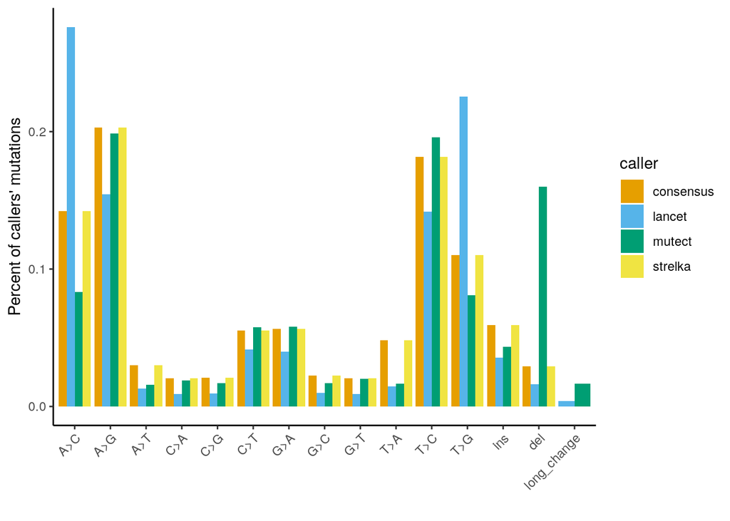

```r
frac_change_df %>%
  ggplot2::ggplot(ggplot2::aes(x = change, y = percent)) +
  ggplot2::theme_classic() +
  ggplot2::geom_bar(
    position = "dodge", stat = "identity",
    ggplot2::aes(fill = caller)
  ) +
  ggplot2::theme(axis.text.x = ggplot2::element_text(angle = 45, hjust = 1)) +
  ggplot2::xlab("") +
  ggplot2::ylab("Percent of callers' mutations") +
  colorblindr::scale_fill_OkabeIto()
```

```r
# Save this plot
ggplot2::ggsave(file.path(plots_dir, "tcga-frac-base-change-plot.png"))
```

## Mutation region barplot

Summarize `Variant_Classification` information per caller.

```r
# Summarize by the number of times each base change shows up in each category.
frac_var_df <- vaf_df %>%
  # Summarize the number of mutations per caller
  dplyr::count(caller, Variant_Classification, name = "count") %>%
  dplyr::add_count(caller, wt = count) %>%
  # Calculate the percent of each
  dplyr::mutate(percent = count / n)
```

Make a barplot illustrating the percent of the mutations for each caller that that are each type of change.

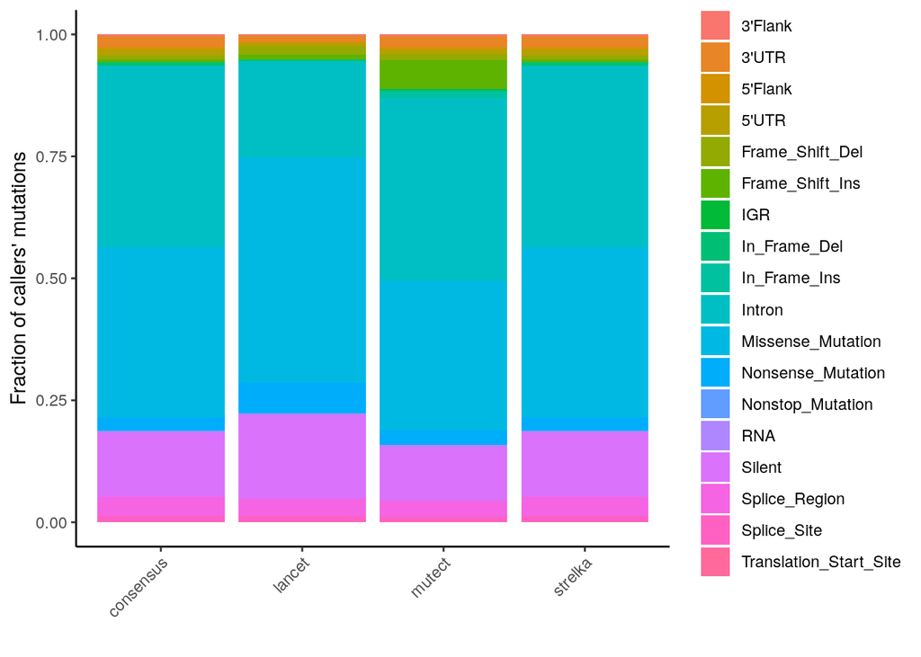

```r
frac_var_df %>%
  ggplot2::ggplot(ggplot2::aes(x = caller, y = percent)) +
  ggplot2::theme_classic() +
  ggplot2::geom_bar(
    position = "stack", stat = "identity",
    ggplot2::aes(fill = Variant_Classification)
  ) +
  ggplot2::theme(axis.text.x = ggplot2::element_text(angle = 45, hjust = 1)) +
  ggplot2::xlab("") +
  ggplot2::ylab("Fraction of callers' mutations")
```

```r
# Save this plot
ggplot2::ggsave(file.path(plots_dir, "tcga-variant-classification-plot.png"))
```